# [SLCU R Course](https://tavareshugo.github.io/slcu_r_course/)

## Data Visualization with R - exercise solutions

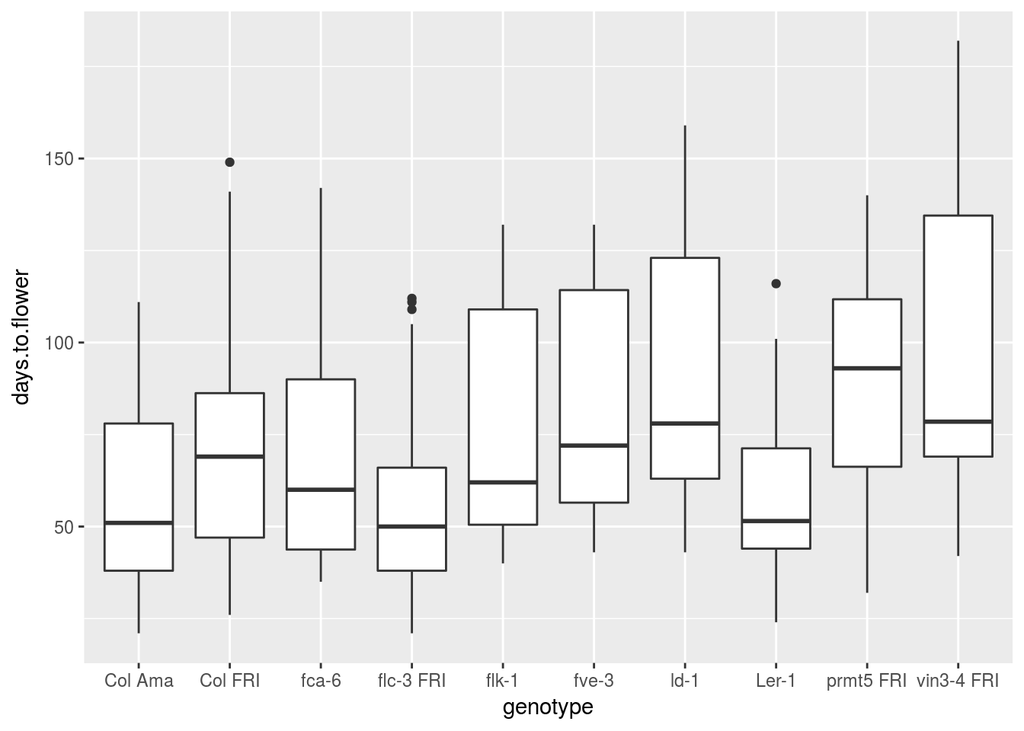

```r
ggplot(expt1, aes(genotype, days.to.flower)) +
  geom_boxplot()
```

> **Challenge:** can you modify this plot so that the points appear on top of the boxplots rather than behind them?

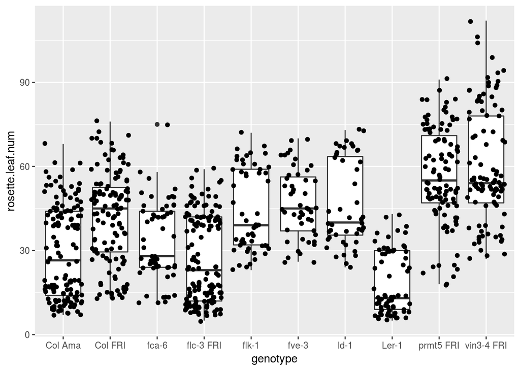

```r
ggplot(expt1, aes(genotype, rosette.leaf.num)) +
  geom_boxplot() +
  geom_jitter()
```

> **Challenge:** say we are particularly interested in the relationship between number of rosette leafs and blade length in mm per genotype.

> Visualize this relationship with a scatter plot (`geom_point()`) between `blade.length.mm` and `rosette.leaf.num` and colour the points by `genotype`.

> What happens if you colour the points by `days.to.bolt`?

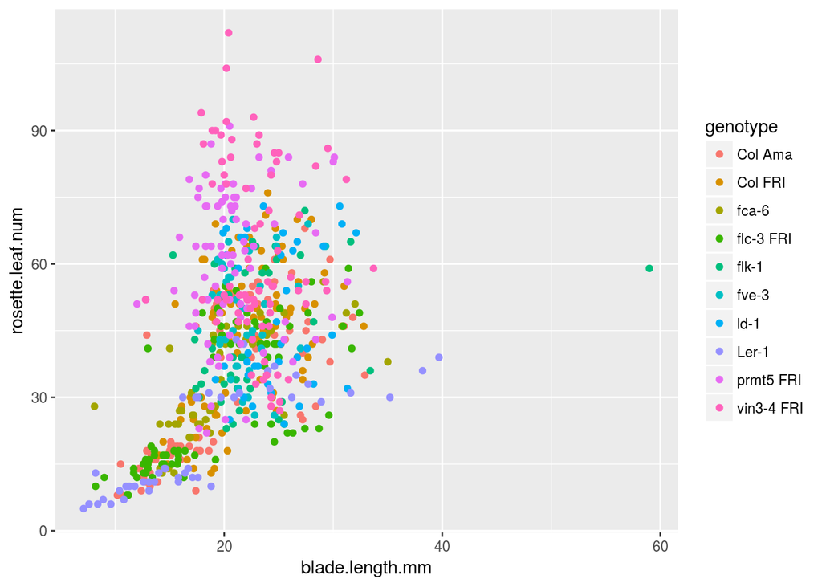

```r
ggplot(expt1, aes(blade.length.mm, rosette.leaf.num, colour = genotype)) +
  geom_point()
```

If we colour the points by `days.to.bolt` the colour scale is continuous rather than discrete (because `days.to.bolt` is a numeric variable):

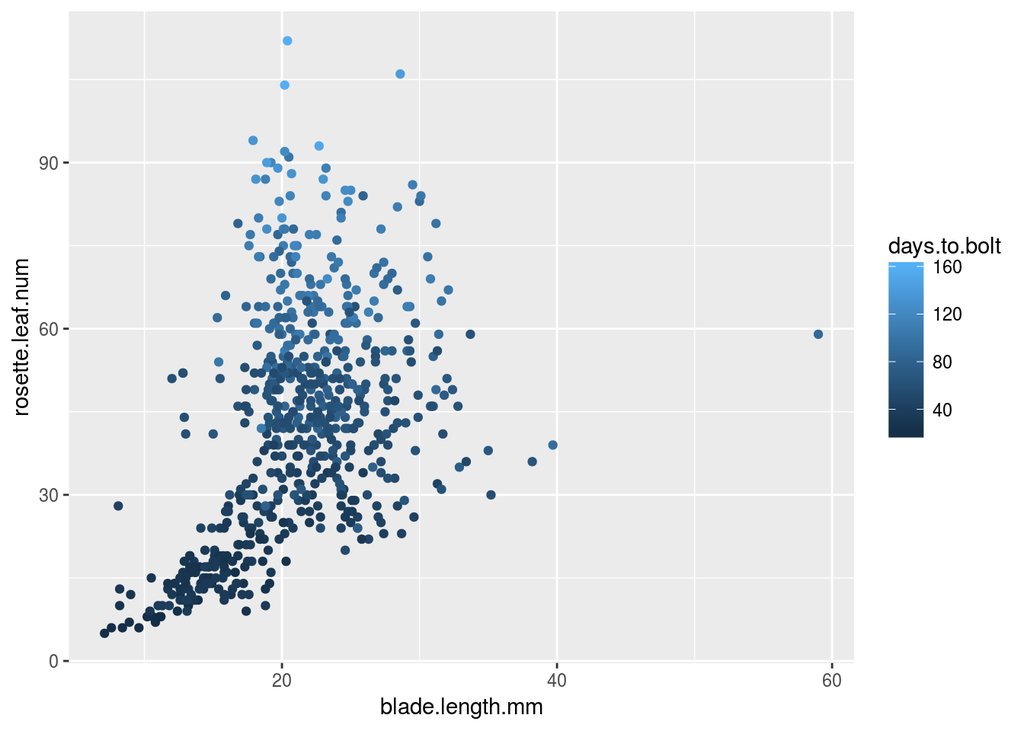

```r
ggplot(expt1, aes(blade.length.mm, rosette.leaf.num, colour = days.to.bolt)) +
  geom_point()
```

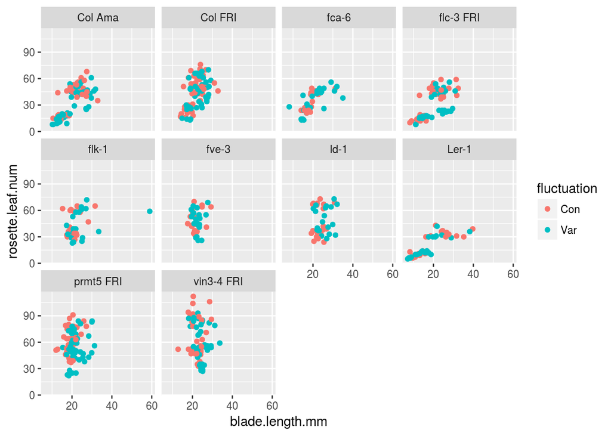

```r
ggplot(expt1, aes(blade.length.mm, rosette.leaf.num, colour = fluctuation)) +
    geom_point() +
    facet_wrap( ~ genotype)
```

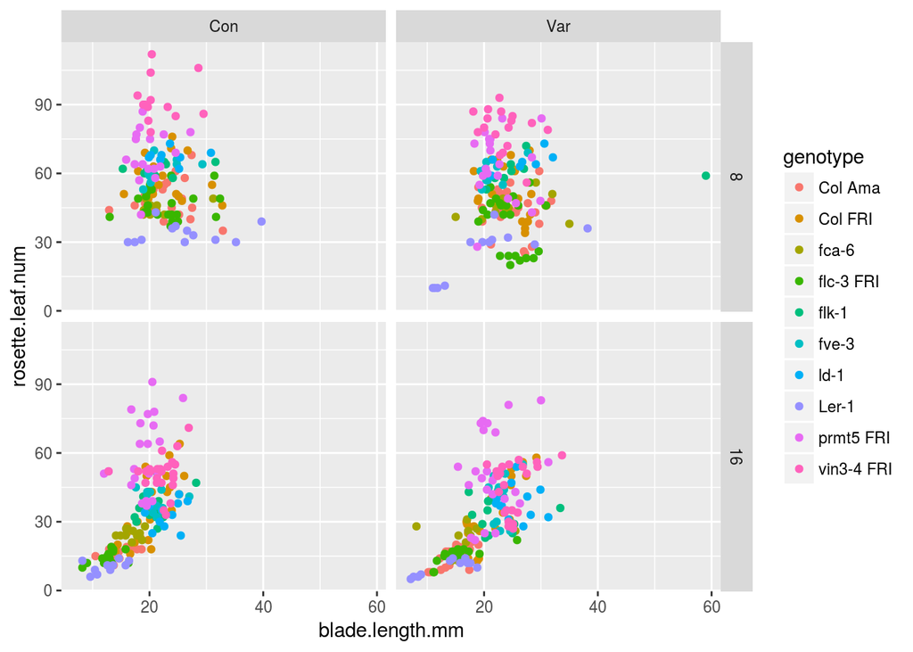

```r
ggplot(expt1, aes(blade.length.mm, rosette.leaf.num, colour = genotype)) +
    geom_point() +
    facet_grid(day.length ~ fluctuation)
```

> **Challenge**: Can you produce a graph similar to

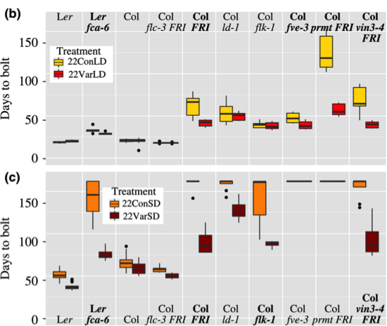

> .

> **Hint**: facet the plot by `day.length` and `temperature` and fill the boxplots by `fluctuation`.

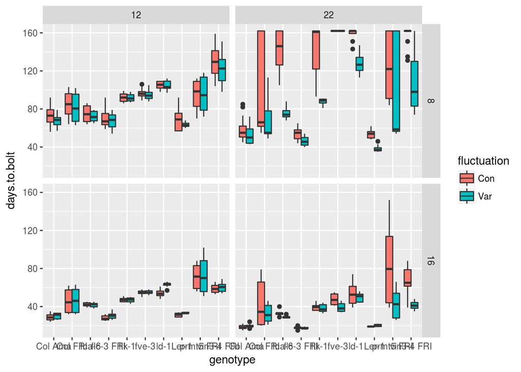

```r
ggplot(expt1, aes(genotype, days.to.bolt, fill = fluctuation)) +
    geom_boxplot() +
    facet_grid(day.length ~ temperature)
```